# Orca Census Data Work

```r
library(tidyverse)
library(here)
library(lme4)
```

```r
orcaCensus <- read.csv(here("NRKW Population 1.csv"))
#orcaCensus <- read.csv("C:/Users/Owner/Desktop/fall 23'/EEB 313/NRKW Population 1.csv")
```

# Salmon Data Gen

The orca census data does not include this so we have to generate this data if we want to include it in our models.

Chum generator based on Salmon data collection from: https://www.npafc.org/wp-content/uploads/Public-Documents/2009/1199Rev1WGSA.pdf (pg 51 (BC Chum Salmon))

For each year from 1980 to 2010 need to randomly select a salmon quantity. Hypothetically, the abundance would go down towards the 2000’s but for this beginning function I’m just gonna have it choose randomly.

Data set above: Min value: 0.46 (million) Max Value: 6.17 (million)

## Chum Generator

```r
# Create the years for the model
years_measured<-(c(seq(1980,2010,1)))
# Numbers are in millions of fish
chum_generator <- function(){
  # Choosing a random value 0.46 - 6.17, replacement is true
  chum_abundance <- sample(x = seq(0.46,6.17,0.02),
                           size = length(years_measured),
                           replace = T)
  # Making data frame for each year, including the random abundance
  yearly_chum <- data.frame(years_measured, chum_abundance)
  return(yearly_chum)
  }
```

## Chinook Generator

Based on https://www.npafc.org/wp-content/uploads/Public-Documents/2009/1199Rev1WGSA.pdf (pg 123) From 1980- 2008 (in millions of fish) Min value: 0.13 Max Value: 1.27

```r
# Numbers are in millions of fish
chinook_generator <- function(){
  # Choosing a random value between 0.13 and 1.27, replacement is true
  chinook_abundance <- sample(x = seq(0.13,1.27,0.02),
                            size = length(years_measured),
                            replace = T)
  # Making data frame for each year and with the random density
  yearly_chinook <- data.frame(years_measured, chinook_abundance)
  return(yearly_chinook)
  }
```

## Generator for Salmon in DF format

```r
salmon <- data.frame(chinook_generator(), chum_generator())

salmon_data<-salmon %>%
  select(years_measured,chinook_abundance,chum_abundance) %>%
  mutate(total_salmon = chinook_abundance + chum_abundance)
```

# Orca Census Data

## Exploratory Plotting

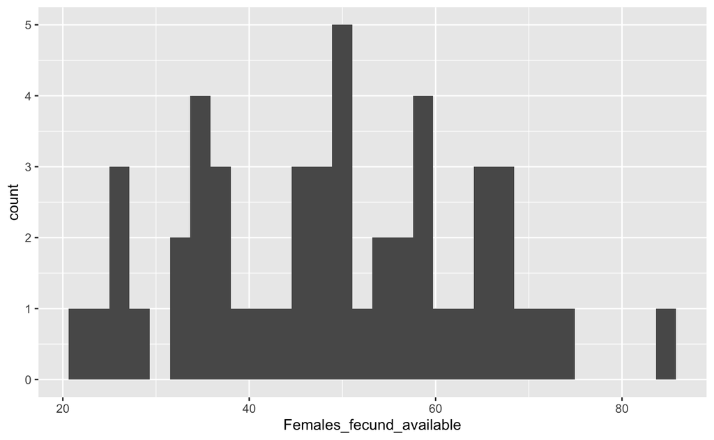

```r
library(ggplot2)

ggplot(data = orcaCensus, aes(x = Females_fecund_available)) +
  geom_histogram()
```

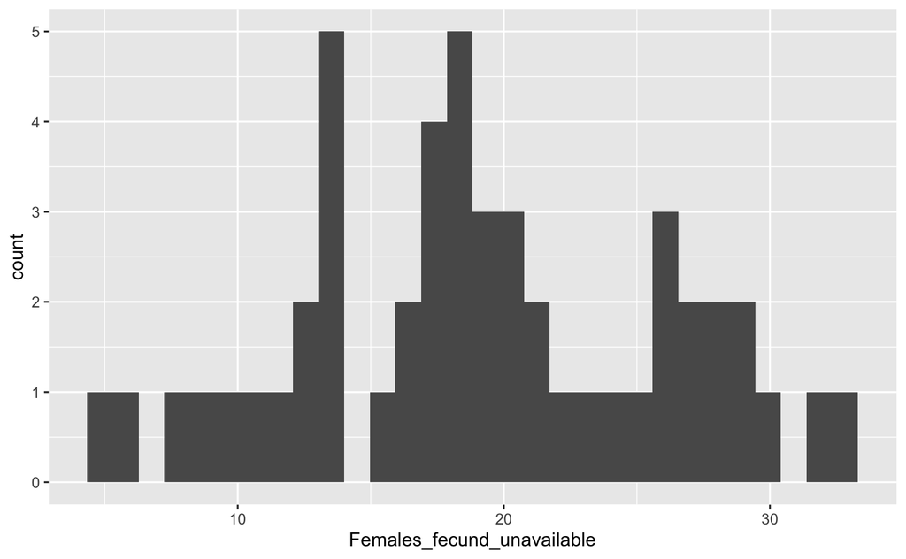

```r
# potential proxy variables for lactating females

ggplot(data = orcaCensus, aes(x = Females_fecund_unavailable)) +
  geom_histogram()
```

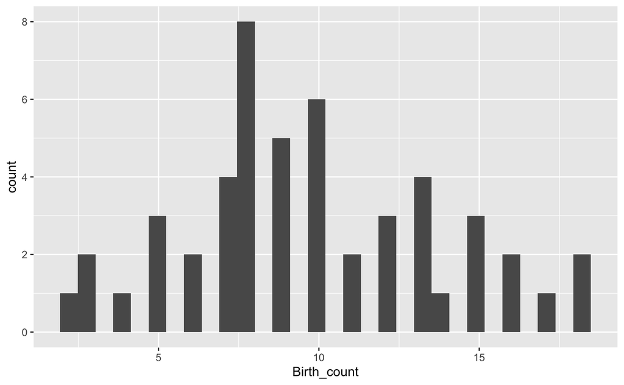

```r
ggplot(data = orcaCensus, aes(x = Birth_count)) +
  geom_histogram()
```

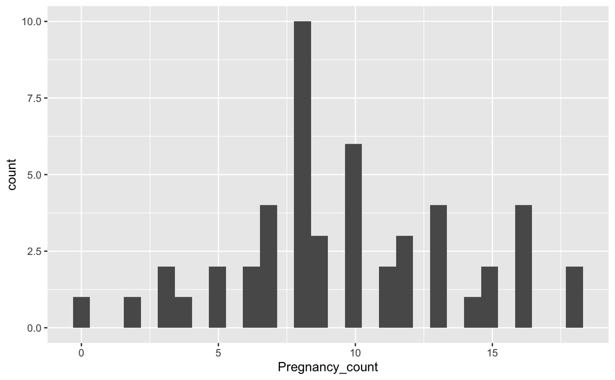

```r
ggplot (data = orcaCensus, aes(x = Pregnancy_count)) +
  geom_histogram()
```

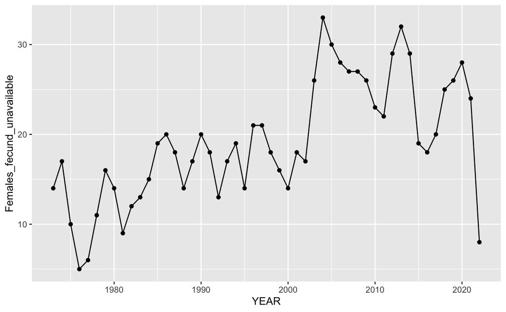

```r
# Looking at the variables over time

ggplot(data = orcaCensus, aes(YEAR, Females_fecund_unavailable)) +
  geom_point()+
  geom_line()
```

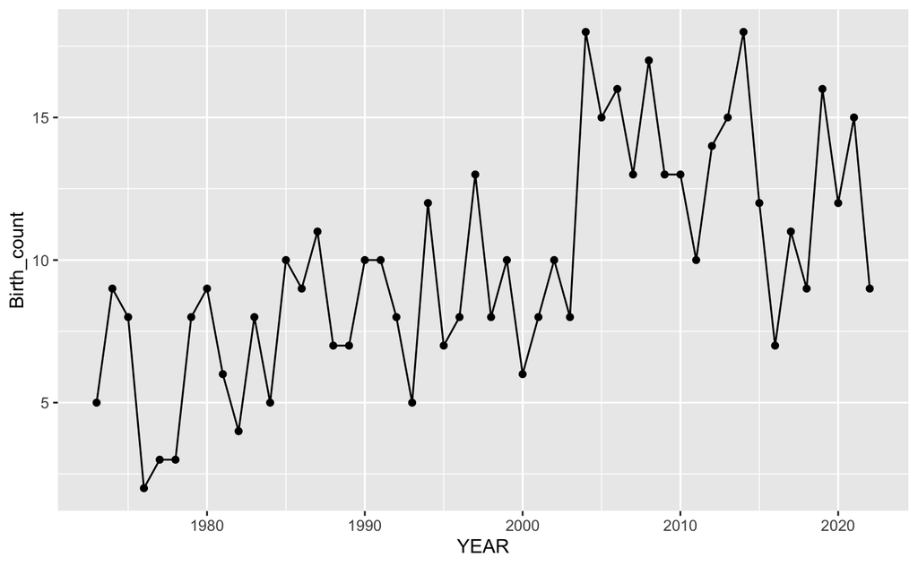

```r
ggplot(data = orcaCensus, aes(YEAR, Birth_count)) +
  geom_point()+
  geom_line()
```

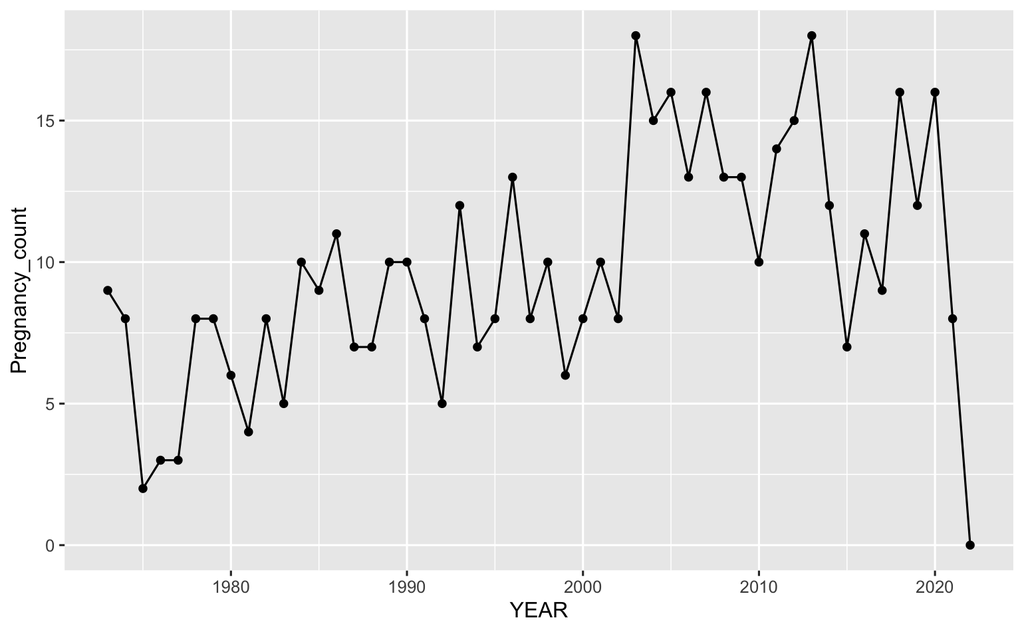

```r
ggplot(data = orcaCensus, aes(YEAR, Pregnancy_count)) +
  geom_point()+
  geom_line()
```

## Data Wrangling and Splitting for Pods

```r
# A list of the number of pods each year, as determined by Fig 1c
# in Stredulinsky et.al 2021
pods_List <- c(20,18,18,20,21,17,16,21,21,20,21,20,24,26,25,25,
               25,25,24,25,25,25,24,21,22,23,23,25,25,23,24)

# The purpose of the while loop below is to give each pod in a year it's own
# row, so that we can then give each pod it's own pod size. For example,
# for the year 1980 there will be 20 rows, with pods 1-20.

# Create a data frame to hold the estimated pod data
pods_Data <- data.frame()

# Initialize both counters at one
x <- 1
i <- 1

# While x is less than the total number of pods in the study period
while(x < sum(pods_List)){
  # Set the year
  year <- i+1979

  # Take the rows from the end of the last year's pods to the end of this
  # year's pods, where each pod is it's own row
  pods_Data[c(x:((x-1)+pods_List[i])),1] <- year # add the year for each row
  # Add a pod ID number for each pod present in the year
  pods_Data[c(x:((x-1)+pods_List[i])),2] <- c(1:pods_List[i])

  x <- x+pods_List[i] # Increase the rows to the end of this year's pods
  i <- i+1 # Increase the year by one
}

colnames(pods_Data) <- c("Year", "Pod_Num") # create column names

# initialize a data frame to hold individual pod sizes
pod_Multinom_Sizes <- data.frame()

n <- 31 # Set the number of years in the study

# The purpose of the for loop below is to generate a pod size, females with
# fecundity unavailable count, births count, and pregnancy count for each pod.

for(i in 1:n){ #generate pod sizes
  # Set the exact year
  year <- i+1979

  # Take the total counts in a year from the orca census data where the year
  # is equal to the current year in the loop
  s_Total <- orcaCensus$Size_best[orcaCensus$YEAR==year]
  s_Fecund_Unav <- orcaCensus$Females_fecund_unavailable[orcaCensus$YEAR==year]
  s_Births <- orcaCensus$Birth_count[orcaCensus$YEAR==year]
  s_Pregnancy <- orcaCensus$Pregnancy_count[orcaCensus$YEAR==year]

  # Generate pod sizes as a multinomial with a size equal to the total number
  # of orcas in that year, for the number of pods in that year where each
  # pod size has an equal chance of occurring.
  size_Pod <- rmultinom(1, size = s_Total,
                        prob = rep(1,pods_List[i]))
  # Perform the same process as above for births, pregancies, and females with
  # fecundity unavailable.
  size_Fecund_Unav_Pod <- rmultinom(1, size = s_Fecund_Unav,
                                    prob = rep(1,pods_List[i]))
  size_Births_Pod <- rmultinom(1, size = s_Births,
                                    prob = rep(1,pods_List[i]))
  size_Pregnancy_Pod <- rmultinom(1, size = s_Pregnancy,
                                    prob = rep(1,pods_List[i]))

  # Combine the data into a data frame
  pod_size_by_group <- data.frame(year, size_Pod, size_Fecund_Unav_Pod,
                                  size_Births_Pod, size_Pregnancy_Pod)

  # Bind each new year of data into one data frame
  pod_Multinom_Sizes <- rbind(pod_Multinom_Sizes, pod_size_by_group)
}

# Put the pod size, birth count, pregnancy count, and females with fecundity
# unavailable into the data frame with year and pod ID
pods_Data <- pods_Data %>% mutate(Pod_Size_Multinom =
                                    pod_Multinom_Sizes$size_Pod)
pods_Data <- pods_Data %>% mutate(Fecund_Unav_Multinom =
                                    pod_Multinom_Sizes$size_Fecund_Unav_Pod)
pods_Data <- pods_Data %>% mutate(Births_Multinom =
                                    pod_Multinom_Sizes$size_Births_Pod)
pods_Data <- pods_Data %>% mutate(Pregnancy_Multinom =
                                    pod_Multinom_Sizes$size_Pregnancy_Pod)
```

The salmon data has to be formatted to fit the pod data, since there are now multiple rows per year. To do this, salmon abundances for a given year are repeated for the number of rows in that year.

```r
# Create a data frame to hold the repeated salmon data
rep_salmon_data <- data.frame(chinook_abundance = c(),
                                chum_abundnace = c(),
                                total_salmon = c())

# Initialize both counters at one
x <- 1
i <- 1

# The purpose of the while loop below is to give each row the salmon data for
# the corresponding year of that row. For example, for the year 1980, the
# salmon data for 1980 will be added to each of the 20 rows

while(x < sum(pods_List)){
  # Take the rows from the end of the last year to the end of the current
  # year in the loop, and add salmon data for the corresponding year
  rep_salmon_data[c(x:((x-1)+pods_List[i])),1] <- salmon_data[i,2]
  rep_salmon_data[c(x:((x-1)+pods_List[i])),2] <- salmon_data[i,3]
  rep_salmon_data[c(x:((x-1)+pods_List[i])),3] <- salmon_data[i,4]

  x <- x+pods_List[i] # Increase rows in repeated salmon data
  i <- i+1 # Increase row in salmon data
}

# Remove an extra row created in the loop
rep_salmon_data <- rep_salmon_data[-c(693),]

# Give the data frame correct column names
colnames(rep_salmon_data) <- c("chinook_abundance", "chum_abundance", "total_salmon")

# Create a data frame with the pod data and salmon data,
# and add each salmon column to it
pods_Salmon_Data <- pods_Data %>%
  mutate(Chinook_Abundance = rep_salmon_data$chinook_abundance)

pods_Salmon_Data <- pods_Salmon_Data %>%
  mutate(Chum_Abundance = rep_salmon_data$chum_abundance)

pods_Salmon_Data <- pods_Salmon_Data %>%
  mutate(Total_Salmon = rep_salmon_data$total_salmon)
```

# GLMM/LMM

## Checking Assumptions

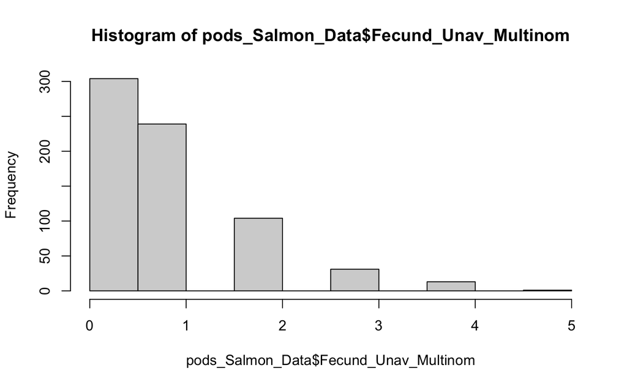

```r
# Create histograms for response and fixed effects to examine normality
hist(pods_Salmon_Data$Fecund_Unav_Multinom)
```

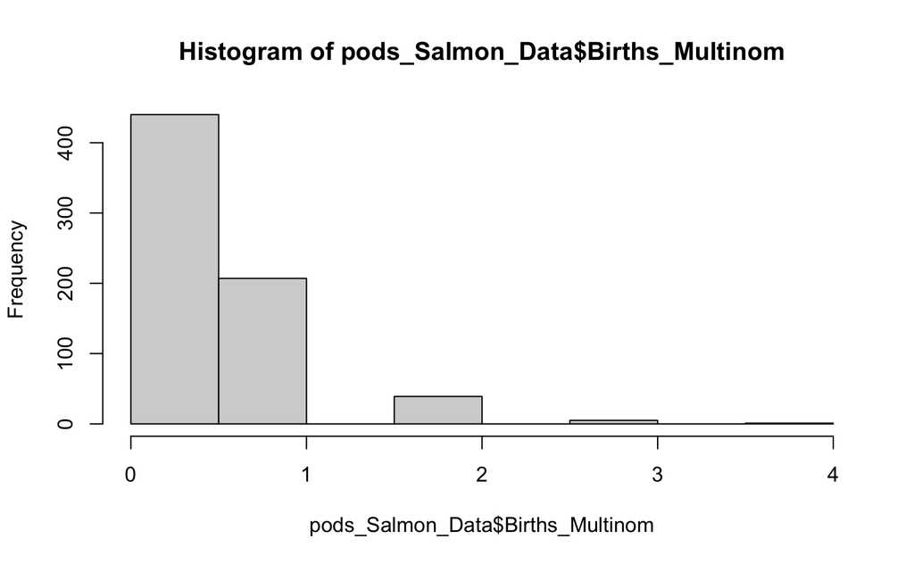

```r
hist(pods_Salmon_Data$Births_Multinom)
```

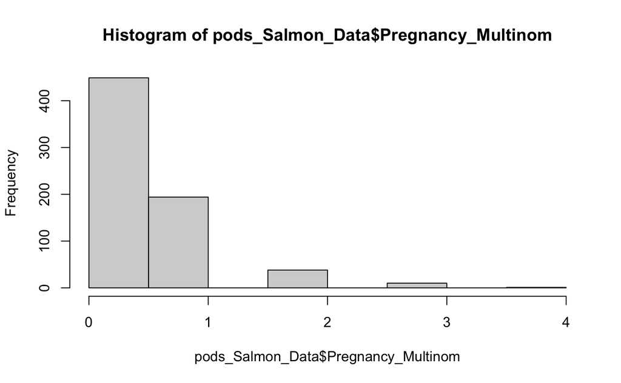

```r
hist(pods_Salmon_Data$Pregnancy_Multinom)
```

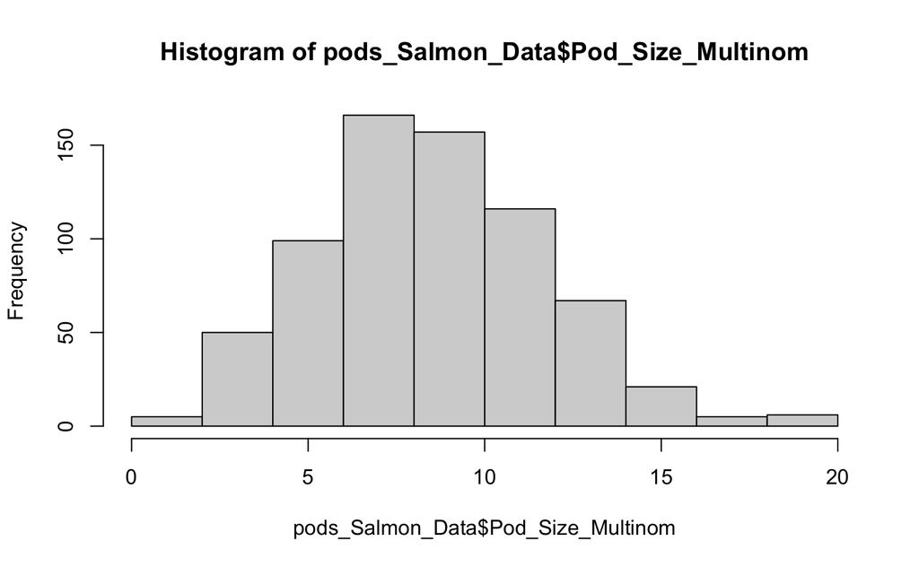

```r
hist(pods_Salmon_Data$Pod_Size_Multinom)
```

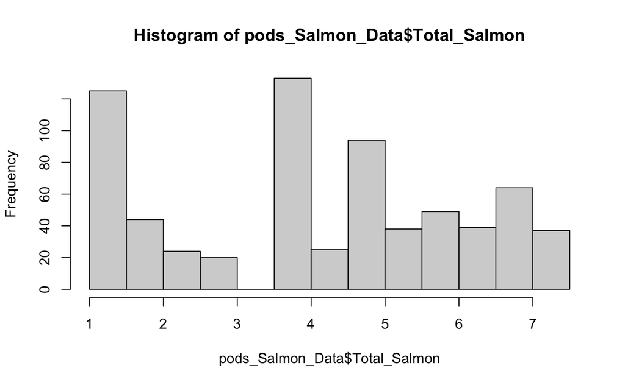

```r
hist(pods_Salmon_Data$Total_Salmon)
```

All proxy measures of lactating females (females with fecundity unavailabe, birth count, pregnancy count) are not normally distributed, so we will use GLMMs

## Pod Model

```r
pod_Fecund_Unav_Model <- glmer(Fecund_Unav_Multinom~Total_Salmon+Pod_Size_Multinom+
                   (1|Pod_Num)+(1|Year),
                 family = poisson, pods_Salmon_Data)
summary(pod_Fecund_Unav_Model)
```

```
Generalized linear mixed model fit by maximum likelihood (Laplace Approximation) ['glmerMod']
 Family: poisson  ( log )
Formula: Fecund_Unav_Multinom ~ Total_Salmon + Pod_Size_Multinom + (1 |      Pod_Num) + (1 | Year)
   Data: pods_Salmon_Data

     AIC      BIC   logLik deviance df.resid
  1719.0   1741.7   -854.5   1709.0      687

Scaled residuals:
    Min      1Q  Median      3Q     Max
-1.1032 -0.8825  0.0187  0.3529  3.7998

Random effects:
 Groups  Name        Variance Std.Dev.
 Year    (Intercept) 0.03617  0.1902
 Pod_Num (Intercept) 0.01797  0.1341
Number of obs: 692, groups:  Year, 31; Pod_Num, 26

Fixed effects:
                  Estimate Std. Error z value Pr(>|z|)
(Intercept)       -0.16177    0.17286  -0.936    0.349
Total_Salmon       0.03401    0.02790   1.219    0.223
Pod_Size_Multinom -0.01697    0.01367  -1.242    0.214

Correlation of Fixed Effects:
            (Intr) Ttl_Sl
Total_Salmn -0.636
Pd_Sz_Mltnm -0.650 -0.055
```

```r
pod_Births_Model <- glmer(Births_Multinom~Total_Salmon+Pod_Size_Multinom+
                   (1|Pod_Num)+(1|Year),
                 family = poisson, pods_Salmon_Data)
```

```
boundary (singular) fit: see help('isSingular')
```

```r
summary(pod_Births_Model)
```

```
Generalized linear mixed model fit by maximum likelihood (Laplace Approximation) ['glmerMod']
 Family: poisson  ( log )
Formula: Births_Multinom ~ Total_Salmon + Pod_Size_Multinom + (1 | Pod_Num) +      (1 | Year)
   Data: pods_Salmon_Data

     AIC      BIC   logLik deviance df.resid
  1193.1   1215.8   -591.5   1183.1      687

Scaled residuals:
    Min      1Q  Median      3Q     Max
-0.7819 -0.6673 -0.6285  0.8182  5.3235

Random effects:
 Groups  Name        Variance Std.Dev.
 Year    (Intercept) 0.004604 0.06785
 Pod_Num (Intercept) 0.000000 0.00000
Number of obs: 692, groups:  Year, 31; Pod_Num, 26

Fixed effects:
                  Estimate Std. Error z value Pr(>|z|)
(Intercept)       -1.16023    0.21233  -5.464 4.65e-08 ***
Total_Salmon       0.01653    0.03064   0.539    0.590
Pod_Size_Multinom  0.02925    0.01837   1.592    0.111
---
Signif. codes:  0 ‘***’ 0.001 ‘**’ 0.01 ‘*’ 0.05 ‘.’ 0.1 ‘ ’ 1

Correlation of Fixed Effects:
            (Intr) Ttl_Sl
Total_Salmn -0.554
Pd_Sz_Mltnm -0.750 -0.057
optimizer (Nelder_Mead) convergence code: 0 (OK)
boundary (singular) fit: see help('isSingular')
```

```r
pod_Pregnancy_Model <- glmer(Pregnancy_Multinom~Total_Salmon+Pod_Size_Multinom+
                   (1|Pod_Num)+(1|Year),
                 family = poisson, pods_Salmon_Data)
```

```
boundary (singular) fit: see help('isSingular')
```

```r
summary(pod_Pregnancy_Model)
```

```
Generalized linear mixed model fit by maximum likelihood (Laplace Approximation) ['glmerMod']
 Family: poisson  ( log )
Formula: Pregnancy_Multinom ~ Total_Salmon + Pod_Size_Multinom + (1 |      Pod_Num) + (1 | Year)
   Data: pods_Salmon_Data

     AIC      BIC   logLik deviance df.resid
  1210.1   1232.8   -600.0   1200.1      687

Scaled residuals:
    Min      1Q  Median      3Q     Max
-0.7607 -0.6687 -0.6305  0.8022  5.5611

Random effects:
 Groups  Name        Variance Std.Dev.
 Year    (Intercept) 0.009392 0.09691
 Pod_Num (Intercept) 0.000000 0.00000
Number of obs: 692, groups:  Year, 31; Pod_Num, 26

Fixed effects:
                  Estimate Std. Error z value Pr(>|z|)
(Intercept)       -1.12814    0.21393  -5.273 1.34e-07 ***
Total_Salmon       0.04078    0.03137   1.300    0.194
Pod_Size_Multinom  0.01451    0.01834   0.791    0.429
---
Signif. codes:  0 ‘***’ 0.001 ‘**’ 0.01 ‘*’ 0.05 ‘.’ 0.1 ‘ ’ 1

Correlation of Fixed Effects:
            (Intr) Ttl_Sl
Total_Salmn -0.573
Pd_Sz_Mltnm -0.730 -0.062
optimizer (Nelder_Mead) convergence code: 0 (OK)
boundary (singular) fit: see help('isSingular')
```

*Note*: I’m not sure how to graph this lol i tried and failed

#Graphing Attempt #2

```r
# pods_Salmon_Data %>%
#  mutate(testing = predict(pod_Fecund_Unav_Model)) %>%  #using model to predict pod fecundity (#not sure if this is right I wonder if it should be predicting like random effects)
#   ggplot(pods_Salmon_Data, aes(x = Total_Salmon, y = Fecund_Unav_Multinom, colour = Year)) +
#   geom_abline(aes(intercept = ))
#
# ggplot(rikz_data, aes(x=NAP, y=Richness, colour=Beach)) +
#
#   # fixed effect regression line (read values off of model output above)
#   geom_abline(aes(intercept=6.5844, slope=-2.5757), linewidth=2) +
#
#   # fitted values (i.e., regression lines) for each beach
#   geom_line(aes(y=fit_InterceptOnly), linewidth=1) +
#   geom_point(size=3)
```

## Total Population Model

I’m gonna see if just looking at the population as a whole matters

```r
# Create a new data frame with years within the study period, then select
# variables used in models, then add salmon data to the data frame.
by_Year_Salmon <- orcaCensus %>% filter(YEAR >= 1980 & YEAR <= 2010)
by_Year_Salmon <- by_Year_Salmon %>% select(YEAR, Size_best,
                                            Females_fecund_unavailable,
                                            Birth_count, Pregnancy_count)
by_Year_Salmon <- by_Year_Salmon %>% mutate(chinook_abundance =
                                              salmon_data$chinook_density)
by_Year_Salmon <- by_Year_Salmon %>% mutate(chum_abundance =
                                              salmon_data$chum_density)
by_Year_Salmon <- by_Year_Salmon %>% mutate(total_salmon =
                                              salmon_data$total_salmon)

pop_Fecund_Unav_Model <- glmer(Females_fecund_unavailable~total_salmon+
                                 Size_best+(1|YEAR),
                 family = poisson, by_Year_Salmon)
```

```
boundary (singular) fit: see help('isSingular')
```

```r
summary(pop_Fecund_Unav_Model)
```

```
Generalized linear mixed model fit by maximum likelihood (Laplace Approximation) ['glmerMod']
 Family: poisson  ( log )
Formula: Females_fecund_unavailable ~ total_salmon + Size_best + (1 |      YEAR)
   Data: by_Year_Salmon

     AIC      BIC   logLik deviance df.resid
   177.7    183.4    -84.8    169.7       27

Scaled residuals:
     Min       1Q   Median       3Q      Max
-1.48477 -0.57354  0.01053  0.35126  2.49677

Random effects:
 Groups Name        Variance Std.Dev.
 YEAR   (Intercept) 0        0
Number of obs: 31, groups:  YEAR, 31

Fixed effects:
             Estimate Std. Error z value Pr(>|z|)
(Intercept)  1.364136   0.316926   4.304 1.68e-05 ***
total_salmon 0.029968   0.022207   1.349    0.177
Size_best    0.007202   0.001343   5.364 8.14e-08 ***
---
Signif. codes:  0 ‘***’ 0.001 ‘**’ 0.01 ‘*’ 0.05 ‘.’ 0.1 ‘ ’ 1

Correlation of Fixed Effects:
            (Intr) ttl_sl
total_salmn -0.508
Size_best   -0.950  0.244
optimizer (Nelder_Mead) convergence code: 0 (OK)
boundary (singular) fit: see help('isSingular')
```

```r
pop_Births_Model <- glmer(Birth_count~total_salmon+
                            Size_best+(1|YEAR),
                 family = poisson, by_Year_Salmon)
```

```
boundary (singular) fit: see help('isSingular')
```

```r
summary(pop_Births_Model)
```

```
Generalized linear mixed model fit by maximum likelihood (Laplace Approximation) ['glmerMod']
 Family: poisson  ( log )
Formula: Birth_count ~ total_salmon + Size_best + (1 | YEAR)
   Data: by_Year_Salmon

     AIC      BIC   logLik deviance df.resid
   154.4    160.2    -73.2    146.4       27

Scaled residuals:
    Min      1Q  Median      3Q     Max
-1.3278 -0.6033  0.0034  0.6770  2.0779

Random effects:
 Groups Name        Variance Std.Dev.
 YEAR   (Intercept) 0        0
Number of obs: 31, groups:  YEAR, 31

Fixed effects:
             Estimate Std. Error z value Pr(>|z|)
(Intercept)  0.568265   0.445048   1.277    0.202
total_salmon 0.020689   0.031087   0.666    0.506
Size_best    0.007971   0.001882   4.235 2.29e-05 ***
---
Signif. codes:  0 ‘***’ 0.001 ‘**’ 0.01 ‘*’ 0.05 ‘.’ 0.1 ‘ ’ 1

Correlation of Fixed Effects:
            (Intr) ttl_sl
total_salmn -0.505
Size_best   -0.951  0.244
optimizer (Nelder_Mead) convergence code: 0 (OK)
boundary (singular) fit: see help('isSingular')
```

```r
pop_Pregnancy_Model <- glmer(Pregnancy_count~total_salmon+
                            Size_best+(1|YEAR),
                 family = poisson, by_Year_Salmon)
```

```
boundary (singular) fit: see help('isSingular')
```

```r
summary(pop_Pregnancy_Model)
```

```
Generalized linear mixed model fit by maximum likelihood (Laplace Approximation) ['glmerMod']
 Family: poisson  ( log )
Formula: Pregnancy_count ~ total_salmon + Size_best + (1 | YEAR)
   Data: by_Year_Salmon

     AIC      BIC   logLik deviance df.resid
   157.9    163.6    -74.9    149.9       27

Scaled residuals:
    Min      1Q  Median      3Q     Max
-1.3342 -0.7394 -0.1478  0.6094  2.1722

Random effects:
 Groups Name        Variance Std.Dev.
 YEAR   (Intercept) 0        0
Number of obs: 31, groups:  YEAR, 31

Fixed effects:
             Estimate Std. Error z value Pr(>|z|)
(Intercept)  0.711485   0.444487   1.601 0.109446
total_salmon 0.039364   0.031187   1.262 0.206887
Size_best    0.006904   0.001883   3.667 0.000246 ***
---
Signif. codes:  0 ‘***’ 0.001 ‘**’ 0.01 ‘*’ 0.05 ‘.’ 0.1 ‘ ’ 1

Correlation of Fixed Effects:
            (Intr) ttl_sl
total_salmn -0.512
Size_best   -0.949  0.246
optimizer (Nelder_Mead) convergence code: 0 (OK)
boundary (singular) fit: see help('isSingular')
```

For females with fecundity unavailable as a lactating females proxy, population size significant For births as a lactating females proxy, population size is significant For pregnancies as a lactating females proxy, population size is significant

Pod Counts Per Year: (From Fig. 1c) 1980: 20 pods 1981: 18 pods 1982: 18 pods 1983: 20 pods 1984: 21 pods 1985: 17 pods 1986: 16 pods 1987: 21 pods 1988: 21 pods 1989: 20 pods 1990: 21 pods 1991: 20 pods 1992: 24 pods 1993: 26 pods 1994: 25 pods 1995: 25 pods 1996: 25 pods 1997: 25 pods 1998: 24 pods 1999: 25 pods 2000: 25 pods 2001: 25 pods 2002: 24 pods 2003: 21 pods 2004: 22 pods 2005: 23 pods 2006: 23 pods 2007: 25 pods 2008: 25 pods 2009: 23 pods 2010: 24 pods